# **Problem Statement**

## **Business Context**

Workplace safety in hazardous environments like construction sites and industrial plants is crucial to prevent accidents and injuries. One of the most important safety measures is ensuring workers wear safety helmets, which protect against head injuries from falling objects and machinery. Non-compliance with helmet regulations increases the risk of serious injuries or fatalities, making effective monitoring essential, especially in large-scale operations where manual oversight is prone to errors and inefficiency.

To overcome these challenges, SafeGuard Corp plans to develop an automated image analysis system capable of detecting whether workers are wearing safety helmets. This system will improve safety enforcement, ensuring compliance and reducing the risk of head injuries. By automating helmet monitoring, SafeGuard aims to enhance efficiency, scalability, and accuracy, ultimately fostering a safer work environment while minimizing human error in safety oversight.

## **Objective**

As a data scientist at SafeGuard Corp, you are tasked with developing an image classification model that classifies images into one of two categories:

- **With Helmet:** Workers wearing safety helmets.
- **Without Helmet:** Workers not wearing safety helmets.

## **Data Description**

The dataset consists of **4125 images**, divided into two categories:

- **With Helmet:** 3161 images showing workers wearing helmets.
- **Without Helmet:** 964 images showing workers not wearing helmets.

**Dataset Characteristics:**

- **Variations in Conditions:** Images include diverse environments such as construction sites, factories, and industrial settings, with variations in lighting, angles, and worker postures to simulate real-world conditions.
- **Worker Activities:** Workers are depicted in different actions such as standing, using tools, or moving, ensuring robust model learning for various scenarios.

# **Installing and Importing the Necessary Libraries**

```python
!pip install tensorflow[and-cuda] scikit-learn==1.6.1 opencv-python==4.12.0.88 seaborn==0.13.2 matplotlib==3.10.0 numpy==2.0.2 pandas==2.2.2 -q
```

**Note:**

- After running the above cell, kindly restart the notebook kernel (for Jupyter Notebook) or runtime (for Google Colab) and run all cells sequentially from the next cell.
- On executing the above line of code, you might see a warning regarding package dependencies. This error message can be ignored as the above code ensures that all necessary libraries and their dependencies are maintained to successfully execute the code in this notebook.

```python
import os
import random
import numpy as np                                                                               # Importing numpy for Matrix Operations
import pandas as pd
import seaborn as sns
import matplotlib.image as mpimg                                                                              # Importing pandas to read CSV files
import matplotlib.pyplot as plt                                                                  # Importting matplotlib for Plotting and visualizing images
import math                                                                                      # Importing math module to perform mathematical operations
import cv2


# Tensorflow modules
import keras
import tensorflow as tf
from tensorflow.keras.preprocessing.image import ImageDataGenerator                              # Importing the ImageDataGenerator for data augmentation
from tensorflow.keras.models import Sequential                                                   # Importing the sequential module to define a sequential model
from tensorflow.keras.layers import Dense,Dropout,Flatten,Conv2D,MaxPooling2D,BatchNormalization # Defining all the layers to build our CNN Model
from tensorflow.keras.optimizers import Adam,SGD                                                 # Importing the optimizers which can be used in our model
from sklearn import preprocessing                                                                # Importing the preprocessing module to preprocess the data
from sklearn.model_selection import train_test_split                                             # Importing train_test_split function to split the data into train and test
from sklearn.metrics import confusion_matrix
from tensorflow.keras.models import Model
from keras.applications.vgg16 import VGG16                                               # Importing confusion_matrix to plot the confusion matrix

# Display images using OpenCV
from google.colab.patches import cv2_imshow

#Imports functions for evaluating the performance of machine learning models
from sklearn.metrics import confusion_matrix, f1_score,accuracy_score, recall_score, precision_score, classification_report
from sklearn.metrics import mean_squared_error as mse                                                 # Importing cv2_imshow from google.patches to display images

# Ignore warnings
import warnings
warnings.filterwarnings('ignore')
```

```python
print("Num GPUs Available:", len(tf.config.list_physical_devices('GPU')))
print(tf.__version__)
```

```
Num GPUs Available: 1
2.19.0
```

```python
# 1. Set Python random seed
random.seed(812)

# 2. Set NumPy random seed
np.random.seed(812)

# 3. Set TensorFlow seed (covers Keras + backend)
tf.keras.utils.set_random_seed(812)

# 4. Enable deterministic GPU ops (if using GPU)
tf.config.experimental.enable_op_determinism()
```

# **Data Overview**

## Loading the data

```python
# Connecting to the Drive
from google.colab import drive
drive.mount('/content/drive')
```

```python
parent_dir = '/content/drive/MyDrive/Learnings/Python_Saved_Path/'
# Load the image file of the dataset
images = np.load(parent_dir+'images.npy')

# Load the labels file of the dataset
labels = pd.read_csv(parent_dir+'labels.csv')
```

```python
# Overview of the data shape
print(images.shape)
print(labels.shape)
```

```
(4125, 200, 200, 3)
(4125, 1)
```

```python
categories=np.unique(labels)
print(categories)
labels.value_counts()
```

```
[0 1]
```

| label | count |
| --- | --- |
| 1 | 3161 |
| 0 | 964 |

**dtype:** int64

### Observations

1. The images and labels have been loaded.
2. There are 4125 images and label.
3. Each Image has length x width of 200 x 200 pixels and 3 channels (RGB)

# **Exploratory Data Analysis**

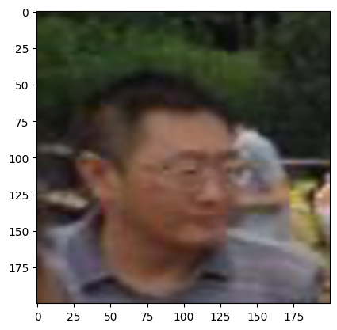

```python
plt.imshow(images[115])
```

#### 1. Average Color Channel Values

```
Mean R: 136.81, Mean G: 125.21, Mean B: 118.29
Std R: 69.56, Std G: 69.23, Std B: 71.99
```

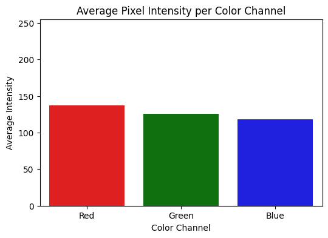

```python
mean_r = np.mean(images[:, :, :, 0])
mean_g = np.mean(images[:, :, :, 1])
mean_b = np.mean(images[:, :, :, 2])

std_r = np.std(images[:, :, :, 0])
std_g = np.std(images[:, :, :, 1])
std_b = np.std(images[:, :, :, 2])

print(f"Mean R: {mean_r:.2f}, Mean G: {mean_g:.2f}, Mean B: {mean_b:.2f}")
print(f"Std R: {std_r:.2f}, Std G: {std_g:.2f}, Std B: {std_b:.2f}")

# Visualize mean channel values
plt.figure(figsize=(6, 4))
sns.barplot(x=['Red', 'Green', 'Blue'], y=[mean_r, mean_g, mean_b], palette=['red', 'green', 'blue'])
plt.title('Average Pixel Intensity per Color Channel')
plt.xlabel('Color Channel')
plt.ylabel('Average Intensity')
plt.ylim(0, 255)
plt.show()
```

### 2. Plot random images from each of the classes and print their corresponding labels.

```python
def plot_images(images,labels):
  categories=np.unique(labels)
  keys=dict(labels['label'])                                                      # Obtaing the unique classes from y_train
  rows = 3                                                                        # Defining number of rows=3
  cols = 4                                                                        # Defining number of columns=4
  fig = plt.figure(figsize=(10, 8))                                               # Defining the figure size to 10x8
  for i in range(cols):
      for j in range(rows):
          random_index = np.random.randint(0, len(labels))                        # Generating random indices from the data and plotting the images
          ax = fig.add_subplot(rows, cols, i * rows + j + 1)                      # Adding subplots with 3 rows and 4 columns
          ax.imshow(images[random_index, :])                                      # Plotting the image
          if keys[random_index] == 0:                                             #Setting the Title based on the label
            ax.set_title('Without Helmet')
          else:
            ax.set_title('With Helmet')
  plt.show()
```

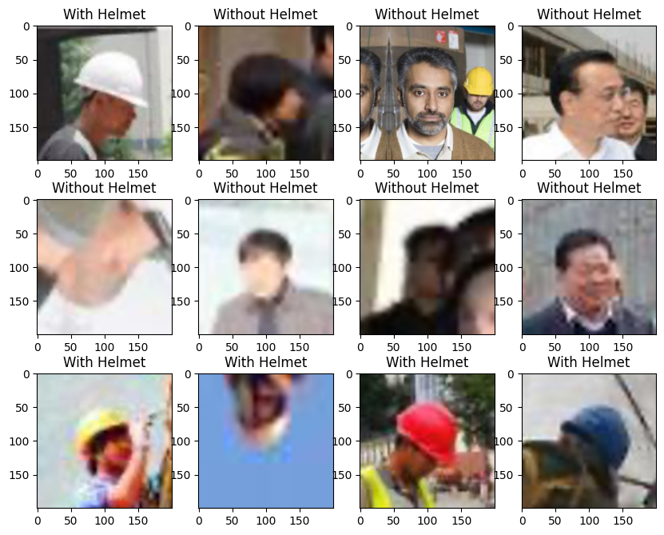

```python
plot_images(images,labels)
```

### 4. Checking for class imbalance

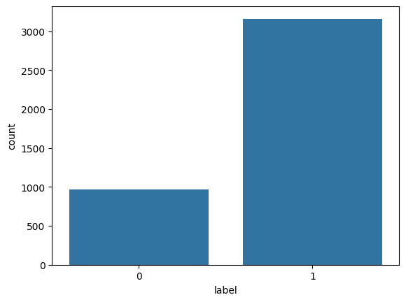

```python
# Creating countplot to check for class imbalance of the categories of 'labels'
categories=np.unique(labels)
sns.countplot(x=labels['label'])
plt.xticks(rotation='horizontal');
```

#### Observations

1. The dataset contains images of workers both 'With Helmet' and 'Without Helmet', as visualized by the random image plots.
2. There is a significant class imbalance in the dataset. As shown by the countplot, the 'With Helmet' class (label 1) has a considerably higher number of instances (3161) compared to the 'Without Helmet' class (label 0), which has 964 instances.
- This imbalance will need to be addressed during model training to prevent the model from being biased towards the majority class.

# **Data Preprocessing**

### Splitting the dataset

- We will use 10% of our data for testing, 10% of our data for validation and 80% of our data for training.
- We are using the train_test_split() function from scikit-learn. Here, we split the dataset into three parts, train,test and validation.

```python
X_train, X_temp, y_train, y_temp = train_test_split(np.array(images),labels , test_size=0.2, random_state=42,stratify=labels)
X_val, X_test, y_val, y_test = train_test_split(X_temp,y_temp , test_size=0.5, random_state=42,stratify=y_temp)
```

```python
#Printing the sape of Training, validation and test data along with their value_counts of labels
print('Training Data:')
print(X_train.shape)
print(y_train.value_counts())
print('%Ratio of 0 and 1:')
print(y_train.value_counts(normalize=True))
print('----------------')
print('\nValidation Data:')
print(X_val.shape)
print(y_val.value_counts())
print('%Ratio of 0 and 1:')
print(y_val.value_counts(normalize=True))
print('----------------')
print('\nTest Data:')
print(X_test.shape)
print(y_test.value_counts())
print('%Ratio of 0 and 1:')
print(y_test.value_counts(normalize=True))
print('----------------')
```

```
Training Data:
(3300, 200, 200, 3)
label
1        2529
0         771
Name: count, dtype: int64
%Ratio of 0 and 1:
label
1        0.766364
0        0.233636
Name: proportion, dtype: float64
----------------

Validation Data:
(412, 200, 200, 3)
label
1        316
0         96
Name: count, dtype: int64
%Ratio of 0 and 1:
label
1        0.76699
0        0.23301
Name: proportion, dtype: float64
----------------

Test Data:
(413, 200, 200, 3)
label
1        316
0         97
Name: count, dtype: int64
%Ratio of 0 and 1:
label
1        0.765133
0        0.234867
Name: proportion, dtype: float64
----------------
```

### Data Normalization

```python
# Convert labels from names to one hot vectors using LabelBinarizer
lb = preprocessing.LabelBinarizer()
y_train_enc = lb.fit_transform(y_train)
y_val_enc = lb.transform(y_val)
y_test_enc = lb.transform(y_test)
```

```python
y_train_enc[0]
```

```
array([1])
```

```python
X_train[0][:5]
```

```
array([[[ 87, 185, 214],
        [ 87, 185, 214],
        [ 87, 185, 214],
        ...,
        [ 81, 181, 235],
        [ 81, 181, 235],
        [ 81, 182, 236]],

       [[ 86, 185, 213],
        [ 86, 185, 213],
        [ 86, 185, 213],
        ...,
        [ 80, 180, 235],
        [ 80, 180, 235],
        [ 80, 181, 236]],

       [[ 85, 184, 213],
        [ 85, 184, 213],
        [ 85, 184, 213],
        ...,
        [ 79, 180, 234],
        [ 79, 180, 234],
        [ 79, 181, 235]],

       [[ 81, 182, 212],
        [ 81, 182, 212],
        [ 81, 182, 212],
        ...,
        [ 76, 179, 233],
        [ 76, 179, 233],
        [ 76, 180, 234]],

       [[ 76, 180, 210],
        [ 76, 180, 210],
        [ 76, 180, 210],
        ...,
        [ 72, 177, 231],
        [ 72, 177, 231],
        [ 72, 178, 232]]], dtype=uint8)
```

Normalization method will be **scaling**

- All the pixel values will be divided by 255 to standardize the images to have values between 0-1.

```python
# Normalizing the image pixels
X_train_normalized = X_train.astype('float32')/255.0
X_val_normalized = X_val.astype('float32')/255.0
X_test_normalized = X_test.astype('float32')/255.0
```

```python
X_train_normalized[0][:5]
```

```
array([[[0.34117648, 0.7254902 , 0.8392157 ],
        [0.34117648, 0.7254902 , 0.8392157 ],
        [0.34117648, 0.7254902 , 0.8392157 ],
        ...,
        [0.31764707, 0.70980394, 0.92156863],
        [0.31764707, 0.70980394, 0.92156863],
        [0.31764707, 0.7137255 , 0.9254902 ]],

       [[0.3372549 , 0.7254902 , 0.8352941 ],
        [0.3372549 , 0.7254902 , 0.8352941 ],
        [0.3372549 , 0.7254902 , 0.8352941 ],
        ...,
        [0.3137255 , 0.7058824 , 0.92156863],
        [0.3137255 , 0.7058824 , 0.92156863],
        [0.3137255 , 0.70980394, 0.9254902 ]],

       [[0.33333334, 0.72156864, 0.8352941 ],
        [0.33333334, 0.72156864, 0.8352941 ],
        [0.33333334, 0.72156864, 0.8352941 ],
        ...,
        [0.30980393, 0.7058824 , 0.91764706],
        [0.30980393, 0.7058824 , 0.91764706],
        [0.30980393, 0.70980394, 0.92156863]],

       [[0.31764707, 0.7137255 , 0.83137256],
        [0.31764707, 0.7137255 , 0.83137256],
        [0.31764707, 0.7137255 , 0.83137256],
        ...,
        [0.29803923, 0.7019608 , 0.9137255 ],
        [0.29803923, 0.7019608 , 0.9137255 ],
        [0.29803923, 0.7058824 , 0.91764706]],

       [[0.29803923, 0.7058824 , 0.8235294 ],
        [0.29803923, 0.7058824 , 0.8235294 ],
        [0.29803923, 0.7058824 , 0.8235294 ],
        ...,
        [0.28235295, 0.69411767, 0.90588236],
        [0.28235295, 0.69411767, 0.90588236],
        [0.28235295, 0.69803923, 0.9098039 ]]], dtype=float32)
```

### Handling Data Imbalance

Oversampling the data in category 0 to get the data to be more balanced

```python
# Initialize ImageDataGenerator with augmentation transformations for the minority class (category 0)
datagen_minority = ImageDataGenerator(
    rotation_range=20, # Rotate images by up to 20 degrees
    width_shift_range=0.1, # Shift images horizontally by up to 10% of the width
    height_shift_range=0.1, # Shift images vertically by up to 10% of the height
    shear_range=0.1, # Apply shear transformation
    zoom_range=0.1, # Apply zoom transformation
    horizontal_flip=True, # Randomly flip images horizontally
    fill_mode='nearest' # Fill new pixels created by transformations with the nearest available pixel
)

# Filter minority class data from the normalized training set
X_train_minority = X_train_normalized[y_train_enc.flatten() == 0]
y_train_minority = y_train_enc[y_train_enc.flatten() == 0]


# Determine how many samples to generate
num_minority_samples = X_train_minority.shape[0] # Current number of minority samples
num_majority_samples = np.sum(y_train_enc == 1) # Current number of majority samples
num_to_generate = num_majority_samples - num_minority_samples # Calculate how many new samples are needed

# Create empty lists to store augmented images and labels
augmented_images = []
augmented_labels = []

# Create a generator for the minority class
# The .flow() method takes arrays of image data and labels and generates batches of augmented data.
minority_generator = datagen_minority.flow(
    X_train_minority,
    y_train_minority,
    batch_size=1, # Generate one image at a time
    shuffle=False # Shuffling is not necessary when generating individual images for concatenation
)

# Generate the required number of augmented images
print(f"Generating {num_to_generate} augmented images for the minority class...")
for i in range(num_to_generate):
    aug_X, aug_y = next(minority_generator) # using next() built-in function
    augmented_images.append(aug_X[0]) # aug_X is a batch, so take the first element
    augmented_labels.append(aug_y[0]) # aug_y is a batch, so take the first element
    if (i + 1) % 500 == 0:
        print(f"Generated {i+1} augmented images...")

# Convert lists to numpy arrays
augmented_images = np.array(augmented_images)
augmented_labels = np.array(augmented_labels)

# Combine augmented data with original training data
X_train_oversampled = np.concatenate((X_train_normalized, augmented_images), axis=0)
y_train_oversampled = np.concatenate((y_train_enc, augmented_labels), axis=0)

print("\nOriginal training data shapes:")
print(f"X_train_normalized: {X_train_normalized.shape}, y_train_enc: {y_train_enc.shape}")
print("\nAugmented minority data shapes:")
print(f"augmented_images: {augmented_images.shape}, augmented_labels: {augmented_labels.shape}")
print("\nOversampled training data shapes:")
print(f"X_train_oversampled: {X_train_oversampled.shape}, y_train_oversampled: {y_train_oversampled.shape}")

# Verify new class distribution
print("\nNew class distribution in y_train_oversampled:")
print(pd.Series(y_train_oversampled.flatten()).value_counts())
```

```
Generating 1758 augmented images for the minority class...
Generated 500 augmented images...
Generated 1000 augmented images...
Generated 1500 augmented images...

Original training data shapes:
X_train_normalized: (3300, 200, 200, 3), y_train_enc: (3300, 1)

Augmented minority data shapes:
augmented_images: (1758, 200, 200, 3), augmented_labels: (1758, 1)

Oversampled training data shapes:
X_train_oversampled: (5058, 200, 200, 3), y_train_oversampled: (5058, 1)

New class distribution in y_train_oversampled:
1    2529
0    2529
Name: count, dtype: int64
```

```python
X_train_oversampled.shape
```

```
(5058, 200, 200, 3)
```

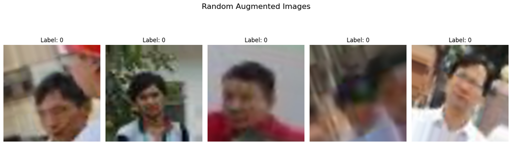

```python
# Helper function to plot images
def plot_augmented_images(images, labels, num_images=5):
    plt.figure(figsize=(15, 5))
    for i in range(num_images):
        random_index = np.random.randint(0, len(images))
        ax = plt.subplot(1, num_images, i + 1)
        plt.imshow(images[random_index])
        plt.title(f"Label: {int(labels[random_index][0])}") # Ensure label is an int for display
        plt.axis('off')
    plt.suptitle('Random Augmented Images', fontsize=16)
    plt.tight_layout(rect=[0, 0.03, 1, 0.95])
    plt.show()

# Visualize some augmented images from the minority class
plot_augmented_images(augmented_images, augmented_labels, num_images=5)
```

### Observations from Data Preprocessing

1. **Data Splitting:**
   - The dataset was successfully split into training (80%), validation (10%), and testing (10%) sets. Specifically:
     - Training data: 3300 images
     - Validation data: 412 images
     - Test data: 413 images
   - Stratified sampling was used during the split, ensuring that the class distribution (approximately 76.6% 'With Helmet' and 23.4% 'Without Helmet') was maintained consistently across all three subsets (training, validation, and test sets).
2. **Data Normalization:**
   - Labels (`y_train`, `y_val`, `y_test`) were successfully converted into one-hot encoded format using `LabelBinarizer` (`y_train_enc`, `y_val_enc`, `y_test_enc`). This is typically done when using binary cross-entropy loss with a single output neuron for binary classification.
   - Image pixel values (`X_train`, `X_val`, `X_test`) were normalized by dividing by 255.0, scaling them to a range of 0 to 1. This helps in faster convergence of the model and improves overall training stability.
3. **Handling Data Imbalance (Oversampling):**
   - The minority class (label 0, 'Without Helmet') in the training set was successfully oversampled using `ImageDataGenerator`.
   - A total of 1758 augmented images were generated for the minority class, increasing its count from 771 to 2529.
   - After oversampling, the `X_train_oversampled` and `y_train_oversampled` datasets now have a balanced class distribution with 2529 samples for 'With Helmet' (label 1) and 2529 samples for 'Without Helmet' (label 0). This addresses the initial class imbalance identified during EDA, which should help prevent the model from being biased towards the majority class.

# **Model Building**

## Model Evaluation Criterion

## Utility Functions

```python
# Function to plot loss, val_loss,
def plot_history(history):
    N = len(history.history["accuracy"])
    plt.figure()
    plt.plot(np.arange(0, N), history.history["accuracy"], label="train_accuracy")
    plt.plot(np.arange(0, N), history.history["val_accuracy"], label="val_accuracy")
    plt.title("Training accuracy Dataset")
    plt.xlabel("Epoch #")
    plt.ylabel("accuracy")
    plt.legend(loc="upper right")
```

```python
# defining a function to compute different metrics to check performance of a classification model built using statsmodels
def model_performance_classification(model, predictors, target):
    """
    Function to compute different metrics to check classification model performance

    model: classifier
    predictors: independent variables (numpy array)
    target: dependent variable (numpy array or pandas Series/DataFrame)
    """
    # Create a temporary ImageDataGenerator for prediction
    # This ensures that prediction also happens in batches, preventing OOM errors
    predict_datagen = ImageDataGenerator()
    predict_generator = predict_datagen.flow(
        predictors,
        batch_size=32, # Using a fixed batch size for prediction
        shuffle=False
    )

    # Get predictions from the model using the generator
    pred_raw = model.predict(predict_generator)

    # checking which probabilities are greater than threshold
    pred = (pred_raw > 0.5).astype(int).reshape(-1) # Ensure pred is 0 or 1 integers

    # Handle target: convert to numpy array if it's a pandas object, and flatten
    if isinstance(target, (pd.Series, pd.DataFrame)):
        target = target.to_numpy().reshape(-1)
    elif isinstance(target, np.ndarray):
        target = target.reshape(-1)
    else:
        raise TypeError("Target must be a pandas Series, DataFrame, or a numpy array.")

    acc = accuracy_score(target, pred)  # to compute Accuracy
    recall = recall_score(target, pred, average='micro')  # to compute Recall
    precision = precision_score(target, pred, average='micro')  # to compute Precision
    f1 = f1_score(target, pred, average='micro')  # to compute F1-score

    # creating a dataframe of metrics
    df_perf = pd.DataFrame({"Accuracy": acc, "Recall": recall, "Precision": precision, "F1 Score": f1,},index=[0],)

    return df_perf
```

```python
def plot_confusion_matrix(model,predictors,target):
    """
    Function to plot the confusion matrix

    model: classifier
    predictors: independent variables (numpy array)
    target: dependent variable (numpy array or pandas Series/DataFrame)
    """
    # Create a temporary ImageDataGenerator for prediction
    predict_datagen = ImageDataGenerator()
    predict_generator = predict_datagen.flow(
        predictors,
        batch_size=32, # Using a fixed batch size for prediction
        shuffle=False
    )

    # Get predictions from the model using the generator
    pred_raw = model.predict(predict_generator)

    # checking which probabilities are greater than threshold
    pred = (pred_raw > 0.5).astype(int).reshape(-1) # Ensure pred is 0 or 1 integers

    # Handle target: convert to numpy array if it's a pandas object, and flatten
    if isinstance(target, (pd.Series, pd.DataFrame)):
        target = target.to_numpy().reshape(-1)
    elif isinstance(target, np.ndarray):
        target = target.reshape(-1)
    else:
        raise TypeError("Target must be a pandas Series, DataFrame, or a numpy array.")

    # Plotting the Confusion Matrix using confusion_matrix() function from sklearn
    cm = confusion_matrix(target,pred)
    f, ax = plt.subplots(figsize=(10, 8))
    sns.heatmap(
        cm,
        annot=True,
        linewidths=.4,
        fmt="d",
        square=True,
        ax=ax
    )
    plt.show()
```

## Model 1: Convolutional Neural Network (CNN) from Scratch

```python
BATCH_SIZE = 32

# Creating a data generator for the oversampled training data
# No additional augmentation needed here, as it was done during oversampling,
# and the data is already normalized.
train_datagen = ImageDataGenerator()
train_generator = train_datagen.flow(
    X_train_oversampled,
    y_train_oversampled,
    batch_size=BATCH_SIZE,
    shuffle=True
)

# Create a data generator for the validation data
# Only normalization is implied if not already done, but X_val_normalized is already normalized.
val_datagen = ImageDataGenerator()
val_generator = val_datagen.flow(
    X_val_normalized,
    y_val_enc,
    batch_size=BATCH_SIZE,
    shuffle=False # No need to shuffle validation data
)
```

Building a first baseline CNN model to classify With and No Helmet.

When building our custom model, Batch Normalization and Dropout layers as regularization techniques have been used to prevent overfitting.

```python
cnn_model_1 = Sequential()
cnn_model_1.add(Conv2D(64, (3,3), activation='relu', input_shape=(200, 200, 3), padding = 'same'))
cnn_model_1.add(MaxPooling2D(2,2))
cnn_model_1.add(BatchNormalization())
cnn_model_1.add(Conv2D(32, (3,3), activation='relu', padding = 'same'))
cnn_model_1.add(MaxPooling2D(2,2))
cnn_model_1.add(BatchNormalization())
cnn_model_1.add(Conv2D(32, (3,3), activation='relu', padding = 'same'))
cnn_model_1.add(MaxPooling2D(2,2))
cnn_model_1.add(Conv2D(16, (3,3), activation='relu', padding = 'same'))
cnn_model_1.add(Flatten())
cnn_model_1.add(Dense(64, activation='relu'))
cnn_model_1.add(Dropout(0.25))
cnn_model_1.add(Dense(32, activation='relu'))
cnn_model_1.add(Dropout(0.25))
cnn_model_1.add(Dense(32, activation='relu'))
cnn_model_1.add(Dense(1, activation='sigmoid'))

cnn_model_1.compile(loss="binary_crossentropy", optimizer="adam", metrics = ['accuracy'])
cnn_model_1.summary()
```

```
Model: "sequential"
```

```
┏━━━━━━━━━━━━━━━━━━━━━━━━━━━━━━━━━┳━━━━━━━━━━━━━━━━━━━━━━━━┳━━━━━━━━━━━━━━━┓
┃ Layer (type)                    ┃ Output Shape           ┃       Param # ┃
┡━━━━━━━━━━━━━━━━━━━━━━━━━━━━━━━━━╇━━━━━━━━━━━━━━━━━━━━━━━━╇━━━━━━━━━━━━━━━┩
│ conv2d (Conv2D)                 │ (None, 200, 200, 64)   │         1,792 │
├─────────────────────────────────┼────────────────────────┼───────────────┤
│ max_pooling2d (MaxPooling2D)    │ (None, 100, 100, 64)   │             0 │
├─────────────────────────────────┼────────────────────────┼───────────────┤
│ batch_normalization             │ (None, 100, 100, 64)   │           256 │
│ (BatchNormalization)            │                        │               │
├─────────────────────────────────┼────────────────────────┼───────────────┤
│ conv2d_1 (Conv2D)               │ (None, 100, 100, 32)   │        18,464 │
├─────────────────────────────────┼────────────────────────┼───────────────┤
│ max_pooling2d_1 (MaxPooling2D)  │ (None, 50, 50, 32)     │             0 │
├─────────────────────────────────┼────────────────────────┼───────────────┤
│ batch_normalization_1           │ (None, 50, 50, 32)     │           128 │
│ (BatchNormalization)            │                        │               │
├─────────────────────────────────┼────────────────────────┼───────────────┤
│ conv2d_2 (Conv2D)               │ (None, 50, 50, 32)     │         9,248 │
├─────────────────────────────────┼────────────────────────┼───────────────┤
│ max_pooling2d_2 (MaxPooling2D)  │ (None, 25, 25, 32)     │             0 │
├─────────────────────────────────┼────────────────────────┼───────────────┤
│ conv2d_3 (Conv2D)               │ (None, 25, 25, 16)     │         4,624 │
├─────────────────────────────────┼────────────────────────┼───────────────┤
│ flatten (Flatten)               │ (None, 10000)          │             0 │
├─────────────────────────────────┼────────────────────────┼───────────────┤
│ dense (Dense)                   │ (None, 64)             │       640,064 │
├─────────────────────────────────┼────────────────────────┼───────────────┤
│ dropout (Dropout)               │ (None, 64)             │             0 │
├─────────────────────────────────┼────────────────────────┼───────────────┤
│ dense_1 (Dense)                 │ (None, 32)             │         2,080 │
├─────────────────────────────────┼────────────────────────┼───────────────┤
│ dropout_1 (Dropout)             │ (None, 32)             │             0 │
├─────────────────────────────────┼────────────────────────┼───────────────┤
│ dense_2 (Dense)                 │ (None, 32)             │         1,056 │
├─────────────────────────────────┼────────────────────────┼───────────────┤
│ dense_3 (Dense)                 │ (None, 1)              │            33 │
└─────────────────────────────────┴────────────────────────┴───────────────┘
```

```
 Total params: 677,745 (2.59 MB)
```

```
 Trainable params: 677,553 (2.58 MB)
```

```
 Non-trainable params: 192 (768.00 B)
```

```python
# Invoking cnn_model_1 with data generators
model_history_1 = cnn_model_1.fit(
    train_generator,
    epochs=10,
    validation_data=val_generator
)
```

```
159/159 ━━━━━━━━━━━━━━━━━━━━ 29s 96ms/step - accuracy: 0.8185 - loss: 0.4154 - val_accuracy: 0.4005 - val_loss: 0.7696
159/159 ━━━━━━━━━━━━━━━━━━━━ 31s 83ms/step - accuracy: 0.8919 - loss: 0.2733 - val_accuracy: 0.5655 - val_loss: 0.9110
159/159 ━━━━━━━━━━━━━━━━━━━━ 13s 81ms/step - accuracy: 0.9031 - loss: 0.2307 - val_accuracy: 0.8301 - val_loss: 0.4063
159/159 ━━━━━━━━━━━━━━━━━━━━ 13s 83ms/step - accuracy: 0.9120 - loss: 0.2228 - val_accuracy: 0.9005 - val_loss: 0.2102
159/159 ━━━━━━━━━━━━━━━━━━━━ 14s 87ms/step - accuracy: 0.9249 - loss: 0.2003 - val_accuracy: 0.9248 - val_loss: 0.1881
159/159 ━━━━━━━━━━━━━━━━━━━━ 12s 73ms/step - accuracy: 0.9298 - loss: 0.1724 - val_accuracy: 0.9272 - val_loss: 0.1729
159/159 ━━━━━━━━━━━━━━━━━━━━ 12s 74ms/step - accuracy: 0.9391 - loss: 0.1614 - val_accuracy: 0.8956 - val_loss: 0.2302
159/159 ━━━━━━━━━━━━━━━━━━━━ 15s 94ms/step - accuracy: 0.9369 - loss: 0.1558 - val_accuracy: 0.9029 - val_loss: 0.2331
159/159 ━━━━━━━━━━━━━━━━━━━━ 14s 91ms/step - accuracy: 0.9446 - loss: 0.1436 - val_accuracy: 0.9175 - val_loss: 0.1993
159/159 ━━━━━━━━━━━━━━━━━━━━ 15s 94ms/step - accuracy: 0.9559 - loss: 0.1120 - val_accuracy: 0.9175 - val_loss: 0.1817
```

```python
# Evaluating on the Test dataset
cnn_model_1.evaluate(X_test_normalized, y_test_enc)
```

```
13/13 ━━━━━━━━━━━━━━━━━━━━ 1s 33ms/step - accuracy: 0.9056 - loss: 0.2538
```

```
[0.25380486249923706, 0.9055690169334412]
```

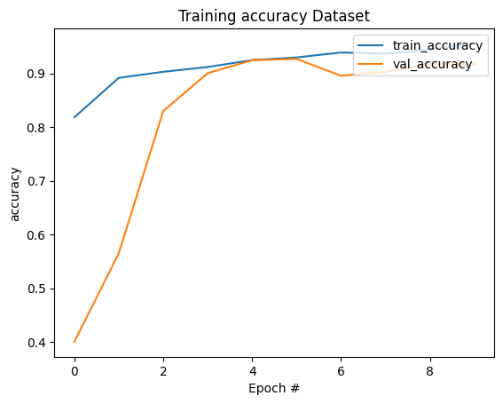

```python
# Plotting the loss vs epoch curve for the basic CNN model without Transfer Learning
plot_history(model_history_1)
```

```python
cnn_model_1_train_perf = model_performance_classification(cnn_model_1, X_train_oversampled,y_train_oversampled)

print("CNN_Model_1 - Train performance metrics")
print(cnn_model_1_train_perf)
```

```
159/159 ━━━━━━━━━━━━━━━━━━━━ 7s 43ms/step
CNN_Model_1 - Train performance metrics
   Accuracy    Recall  Precision  F1 Score
0  0.966785  0.966785   0.966785  0.966785
```

```
159/159 ━━━━━━━━━━━━━━━━━━━━ 5s 32ms/step
```

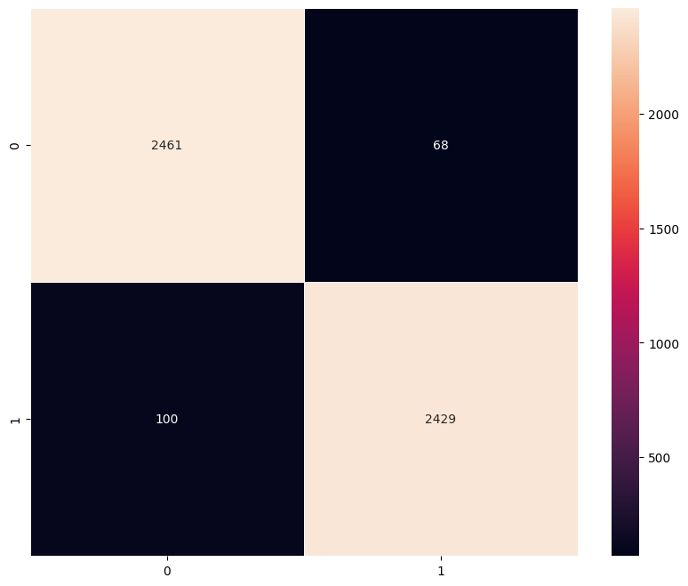

```python
# Assuming `y_train_oversampled` is the intended target after oversampling
# If `y_train_enc` was intended, please change it accordingly.
plot_confusion_matrix(cnn_model_1, X_train_oversampled, y_train_oversampled)
```

```python
cnn_model_1_valid_perf = model_performance_classification(cnn_model_1, X_test_normalized,y_test_enc)

print("CNN_Model_1 - Test performance metrics")
print(cnn_model_1_valid_perf)
```

```
13/13 ━━━━━━━━━━━━━━━━━━━━ 0s 27ms/step
CNN_Model_1 - Test performance metrics
   Accuracy    Recall  Precision  F1 Score
0  0.905569  0.905569   0.905569  0.905569
```

```
13/13 ━━━━━━━━━━━━━━━━━━━━ 0s 24ms/step
```

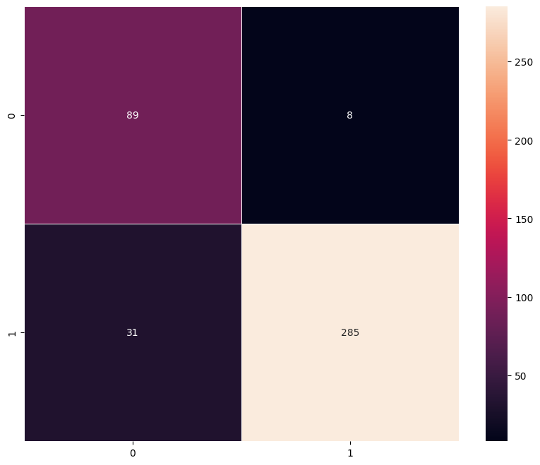

```python
plot_confusion_matrix(cnn_model_1,X_test_normalized,y_test_enc)
```